# Лабораторная работа №1

Julia. Установка и настройка. Основные принципы

Ко Антон Геннадьевич

antonkosakh@gmail.com

Российский университет дружбы народов

2026-09-12

# Информация

## Докладчик

- Ко Антон Геннадьевич
- студент
- Российский университет дружбы народов им. П. Лумумбы
- 1132221551@rudn.ru
- https://SenDerMen04.github.io/ru/

## Цель работы

Основная цель работы — подготовить рабочее пространство и инструментарий для работы с языком программирования Julia, на простейших примерах познакомиться с основами синтаксиса Julia.

Выполнение лабораторной работы

Так как мы используем ОС типа Windows, для различных установок будем использовать менеджер пакетов Chocolatey (https://chocolatey.org/), который установим через Administrative Shell. Но так, как он уже был установлен, вот рисунок того, что он уже есть (рис. #fig:001):

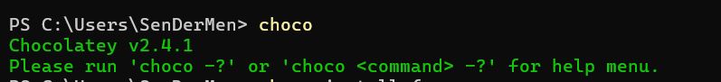

Установка менеджера пакетов Chocolatey

Далее посредством установленного менеджера установим Far Manager, Notepad++, Julia, Anaconda Distribution (Python 3.x) (рис. #fig:002 – #fig:005):

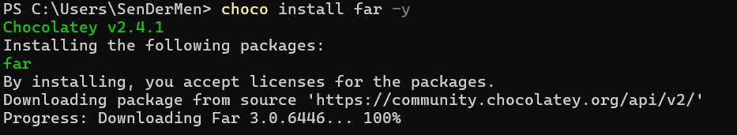

Установка Far Manager

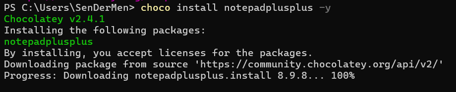

Установка Notepad++

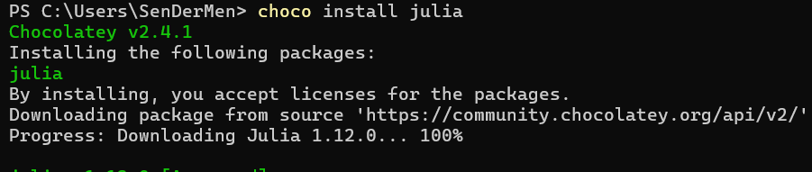

Установка Julia

[figure not shown]

Установка Anaconda Distribution (Python 3.x)

Следующим шагом установим пакеты для работы с Jupyter. Для этого перейдём в пакетный режим Julia, нажав на клавиатуре знак закрывающейся квадратной скобки `]`, затем введём `add IJulia` (рис. #fig:006):

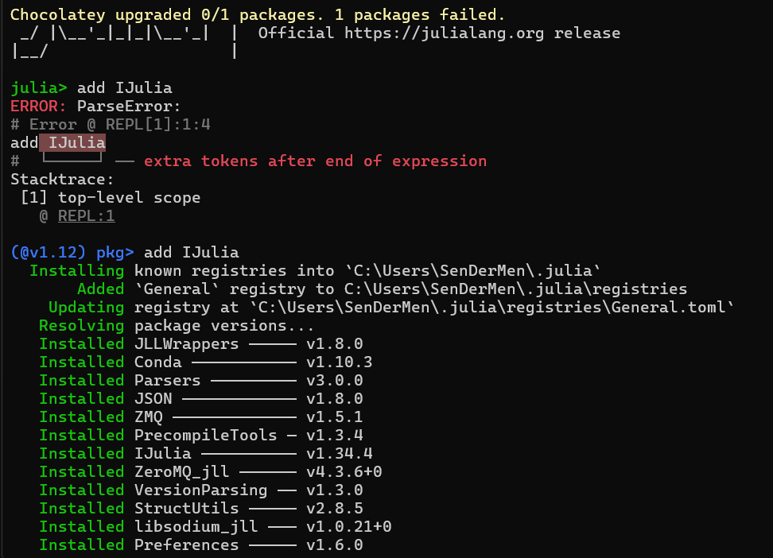

Установка пакетов для работы с Jupyter

Основы синтаксиса Julia на примерах

Для начала потренируемся с определением типов числовых величин (рис. #fig:007):

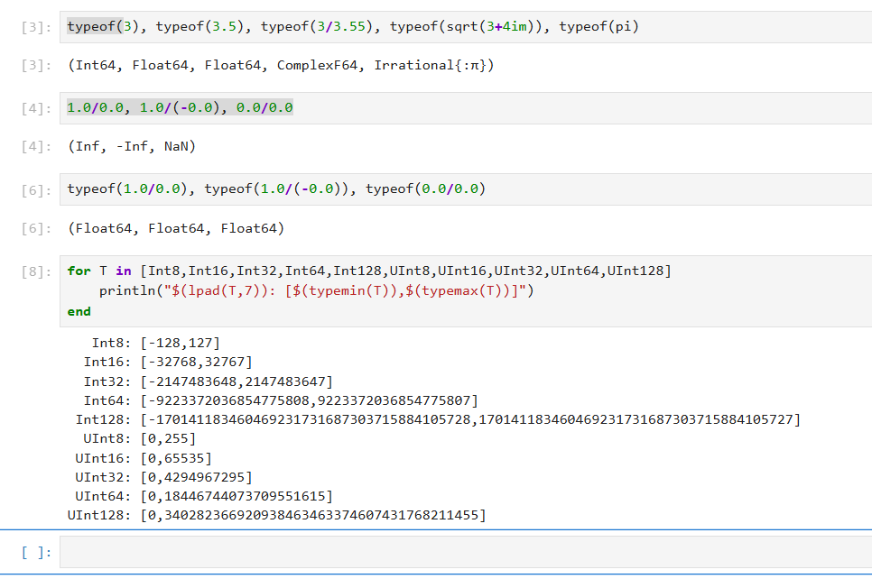

Примеры определения типа числовых величин

После чего приступим к рассмотрению приведения аргументов к одному типу (рис. #fig:008):

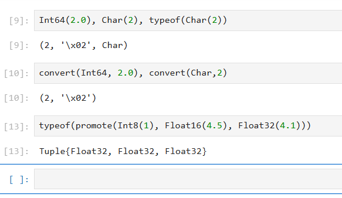

Примеры приведения аргументов к одному типу

И рассмотрим примеры определения функций (рис. #fig:009), а также работу с массивами (рис. #fig:010):

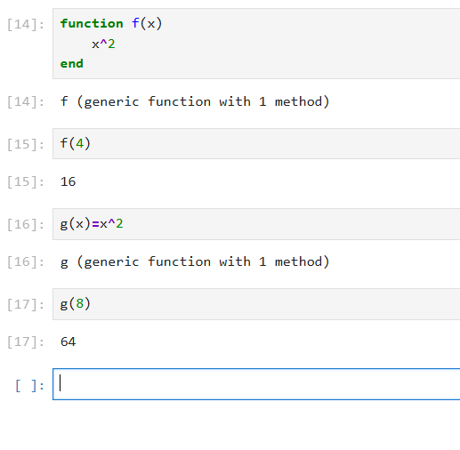

Примеры определения функций

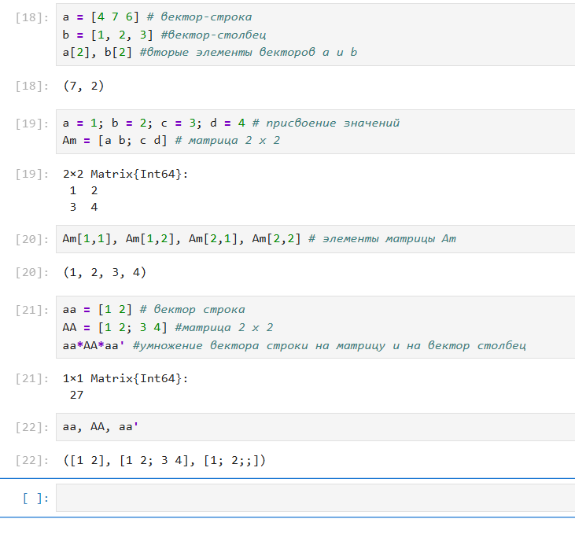

Примеры работы с массивами

### Самостоятельная работа

В первом задании рассмотрим основные функции для чтения / записи / вывода информации на экран. Для этого составим свои примеры (рис. #fig:011):

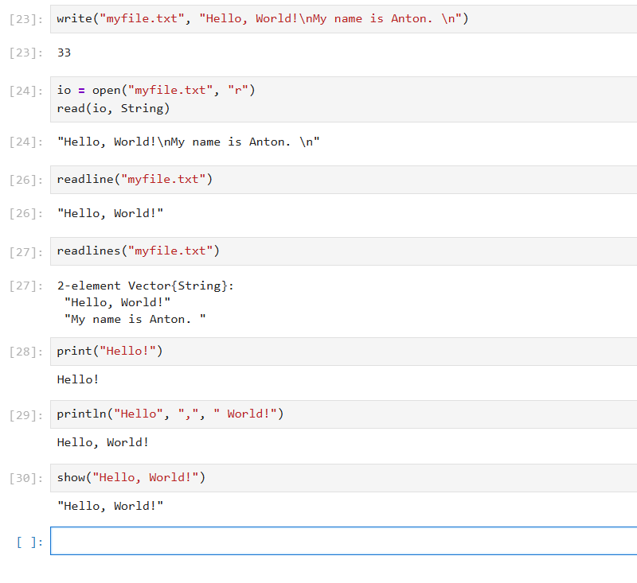

Примеры работы с функциями для чтения/записи/вывода информации на экран

Во втором задании составим пример для функции `parse()` (рис. #fig:012):

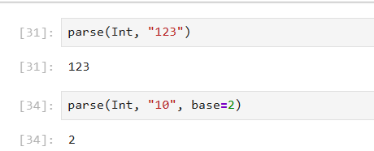

Пример работы с функцией parse

Далее изучим синтаксис Julia для базовых математических операций с разным типом переменных (рис. #fig:013):

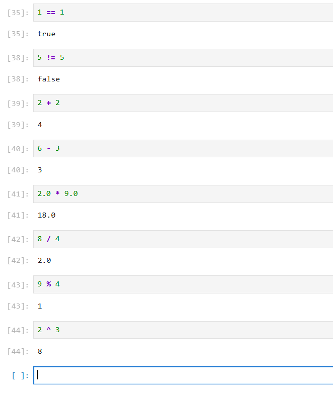

Примеры работы базовых математических операций

В конце работы приведём несколько примеров с операциями над матрицами (рис. #fig:015):

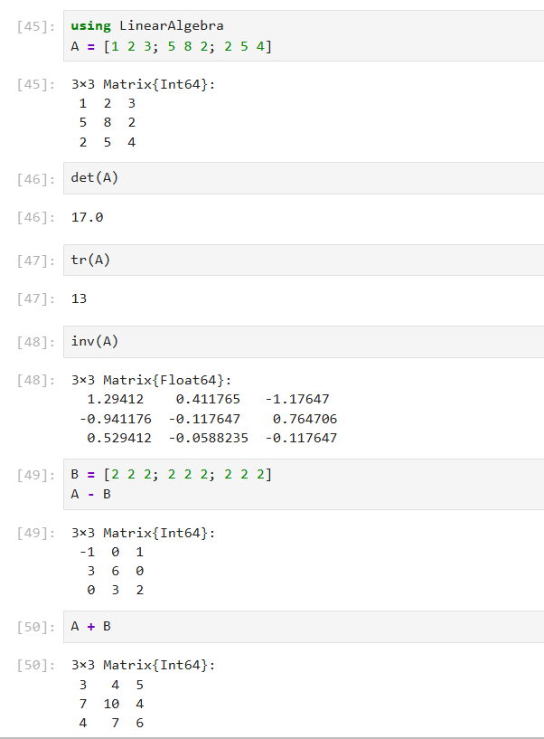

Примеры работы с операциями над матрицами

## Вывод

В ходе выполнения лабораторной работы были получены навыки по подготовке рабочего пространства и инструментария для работы с языком программирования Julia, а также познакомились на простейших примерах с основами синтаксиса Julia.

## Список литературы. Библиография

1. Julia Documentation: https://docs.julialang.org/en/v1/